# aula 21 de maio

Davi Loures

2024-05-21

CASO 2:

$\theta = E[g(x)]=\int g(x)f(x)dx$

$\theta = \int_a^bg(x)dx$

Transformando para uma integral de 0 a 1

$y = \frac{(x-a)}{(b-a)} ,dy = \frac{dx}{(b-a)}$

$x = y(b-a)+a$

$\theta = \int_a^bg(x)dx = \int_0^1g(y(b-a)+a)(b-a)dy=\int^1_0h(y)d(y)$, onde $h(y)=(b-a)g[(y(b-a)+a]$

Exemplo:

$Z\sim N(0,1), \theta = P\{1<Z<2\}=\int_1^2\frac{1}{\sqrt{2\pi}}e^{-\frac{z^2}{2}}dz$

Usando a transformação:

$y = \frac{z-1}{2-1}=z-1$

$h(y)=(b-a)g[(y(b-a)+a]=(2-1)g[y(2-1)+1]=g(y+1)$

logo:

$\theta = \int_0^1\frac{1}{\sqrt{2\pi}}e^{-\frac{(y+1)^2}{2}}dy$

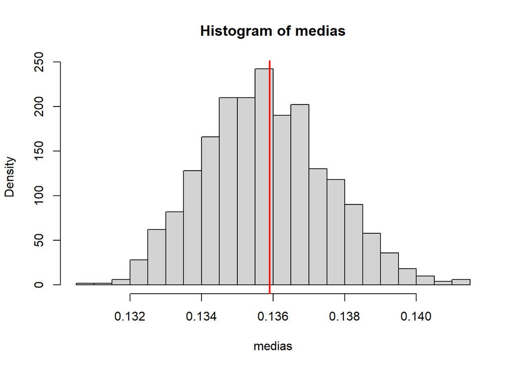

```r
aga <- function(y){
  (1/sqrt(2*pi))*exp(-((y+1)^2)/2)
}
U <- replicate(1000,runif(1000))
agaU <- apply(U,c(1,2),aga)
medias <- apply(agaU,2,mean)
hist(medias, freq = F, breaks = 20)
abline(v = pnorm(2)-pnorm(1), col = "red", lwd = 2)
```

```r
mean(medias)
```

```
## [1] 0.1357847
```

```r
sd(medias)
```

```
## [1] 0.001730943
```

```r
intervalo <- quantile(medias, probs=c(0.025,0.975))
intervalo
```

```
##      2.5%     97.5%
## 0.1326092 0.1393618
```

```r
diff(intervalo)
```

```
##       97.5%
## 0.006752695
```

```r
diff(intervalo)/2
```

```
##       97.5%
## 0.003376348
```

Cálculo do erro quadrático médio:

```r
erro.quad <- mean((medias-(pnorm(2)-pnorm(1)))^2)
log10(erro.quad)
```

```
## [1] -5.521771
```

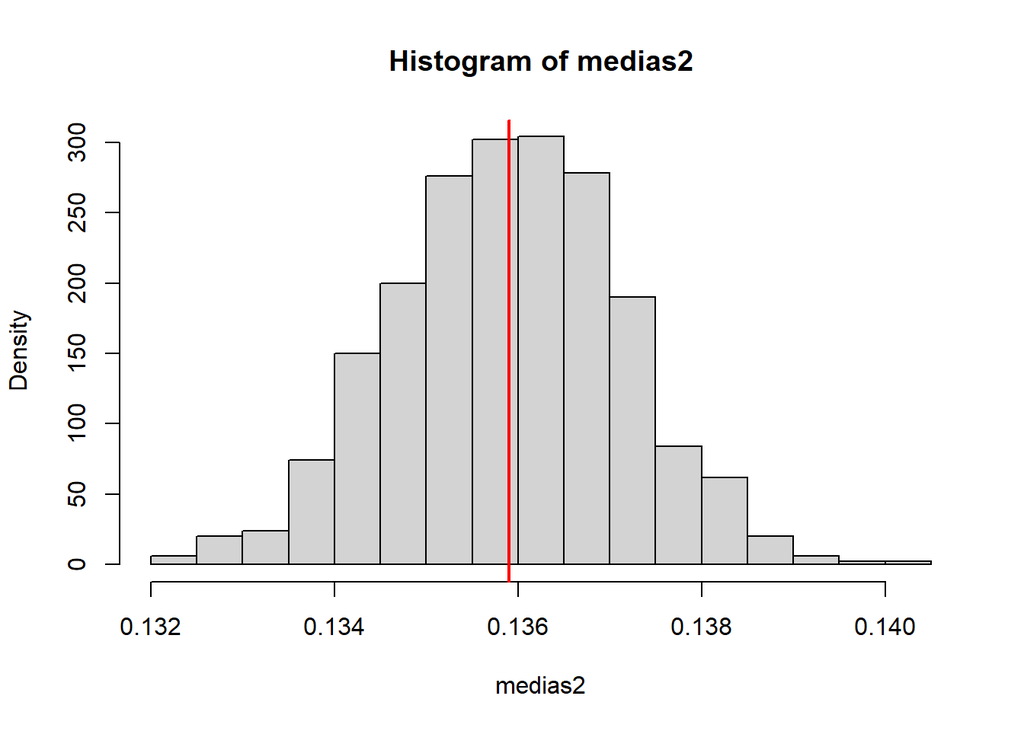

```r
U <- replicate(1000,runif(2000))
agaU <- apply(U,c(1,2),aga)
medias2 <- apply(agaU,2,mean)
hist(medias2, freq = F, breaks = 20)
abline(v = pnorm(2)-pnorm(1), col = "red", lwd = 2)
```

```r
mean(medias2)
```

```
## [1] 0.1358882
```

```r
sd(medias2)
```

```
## [1] 0.001242667
```

```r
intervalo2 <- quantile(medias2, probs=c(0.025,0.975))
intervalo2
```

```
##     2.5%    97.5%
## 0.133541 0.138305
```

```r
diff(intervalo2)
```

```
##       97.5%
## 0.004764009
```

```r
diff(intervalo2)/2
```

```
##       97.5%
## 0.002382005
```

```r
erro.quad <- mean((medias2-(pnorm(2)-pnorm(1)))^2)
log10(erro.quad)
```

```
## [1] -5.811645
```

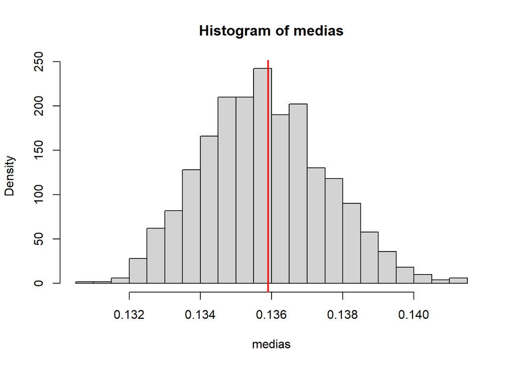

```r
hist(medias, freq = F, breaks = 20)
abline(v = pnorm(2)-pnorm(1), col = "red", lwd = 2)
```

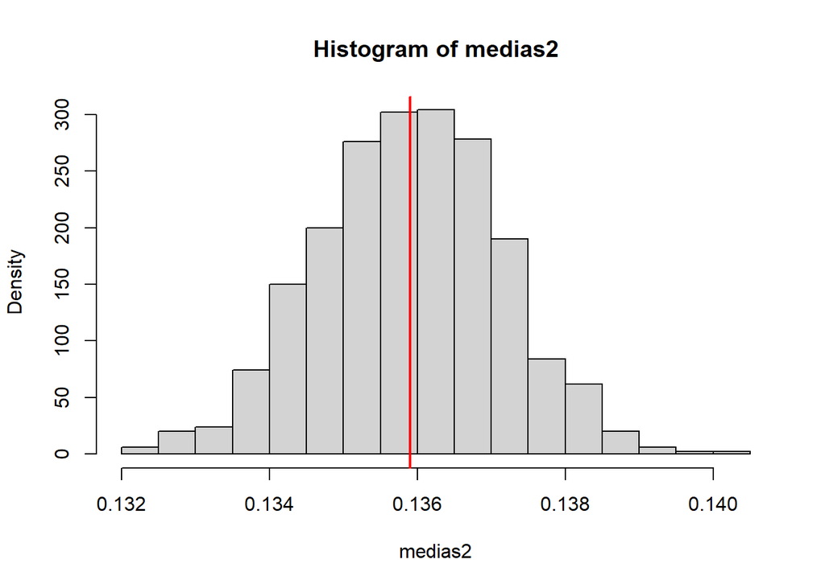

```r
hist(medias2, freq = F, breaks = 20)
abline(v = pnorm(2)-pnorm(1), col = "red", lwd = 2)
```

- CASO 3 - Primeira parametrização

$\theta = \int_0^\infty g(x)dx$

Substituição tipo 1:

$y = \frac{1}{x+1}\rightarrow x = \frac{1}{y}-1,dx = \frac{1}{y^2}dy$, logo, como x varia de 0 a infinito, y varia de 0 a 1

$\theta = \int_1^0g(\frac{1}{y}-1)\frac{(-1)}{y^2}dy=\int_0^1h(y)dy$, onde $h(y) = \frac{g(\frac{1}{y}-1)}{y^2}$

Exemplo:

$\theta = \int_0^\infty e^{-x^2}dx=\frac{\sqrt{\pi}}{2}=$ 0.8862269

```r
aga3 <- function(y){
  exp(-((1/y)-1)^2)/y^2
}
U <- runif(2000)
mean(aga3(U))
```

```
## [1] 0.8938419
```

- CASO 3 - Segunda parametrização

$\theta = \int^\infty_0g(x)dx$

Utilizando a substituição:

$y = \frac{x}{1+x} \rightarrow x = \frac{y}{1-y}$

Assim como na primeira parametrização, quando x vai pra 0, y vai pra 0, e quando x vai pra infinito, y vai pra 1

$dx = \frac{(1-y)-y}{(1-y)^2}$ #VER ISSO AQ

$\theta = \int^1_0g(\frac{y}{1-y})\frac{1}{(1-y^)2}dy \rightarrow \int^1_0h(y)dy$, onde

$h(y) = \frac{g(\frac{y}{1-y})}{(1-y)^2}$

```r
aga4 <- function(y){
exp(-(y/(1-y))^2)/((1-y)^2)
}
U4 <- runif(2000)
mean(aga4(U4))
```

```
## [1] 0.8804824
```

- CASO 3 - Terceira parametrização

$\int^\infty_0f(x)dx=\int^1_0f(x)dx+\int^\infty_1f(x)dx$

Utilizando a substituição:

$y = \frac{1}{x} \rightarrow x = \frac{1}{y}$, logo quando x vai pra 1 y vai pra 1 e quando x vai pra infinito, y vai pra 0

$dx = \frac{-1}{y^2}dy$

Logo, a integral pode ser vista como:

$\int^\infty_0f(x)dx=\int^1_0f(x)dx+\int^0_1f(\frac{1}{y})(-\frac{dy}{d^2})=\int^1_0f(x)dx+\int^0_1f(\frac{1}{y})(-\frac{dy}{d^2})=\int^1_0f(x)dx+\int^0_1f(\frac{1}{y})(\frac{dy}{d^2})$

$= \int^1_0f(x)dx+\int^0_1h(y)dy$, onde $h(y) = \frac{f(\frac{1}{y})}{y^2}$

```r
aga5 <- function(y){
  exp(-(1/y)^2)/y^2
}

Unif1 <- runif(1000)
Unif2 <- runif(1000)
result <- exp(-(Unif1)^2)+ aga5(Unif2)
mean(result)
```

```
## [1] 0.8999187
```

- Estimação de $\pi$

(X,Y) vetor aleatório distribuido em quadrado de lado 2, logo a área do círculo inscito é igual a $\pi$

X,Y iid ~ Unif(-1,1)

área do círculo = (num de pontos dentro do círculo/número de pontos gerados) * 4

pois: Prob(ponto cair dentro do quadrado) = $\frac{\pi}{4}$ ponto é interno ao círculo se: $x^2+y^2\leq1$

1. Gerar U1 e U2 iid ~ Unif(0,1)
2. $X = 2U_1-1,Y=2U_2-1$, para X,Y ~ Unif(-1,1)
3. I = 1 se $x^2+y^2\leq1$ e 0 caso contrário Após n repetições do algoritmo acima, a estimação da probabilidade do ponto cair no círculo vai ser a média da variável indicadora A estimativa de pi vai ser a estimativa de I*4

```r
estima.pi <- function(n){
  U1 <- runif(n)
  U2 <- runif(n)
  X <- 2*U1 - 1
  Y <- 2*U2 - 1
  I <- X^2+Y^2<=1
  mean(I)*4
}
amostra <- replicate(1000,estima.pi(1000))
quantis <- quantile(amostra, c(0.05,0.95))
quantis
```

```
##    5%   95%
## 3.052 3.228
```

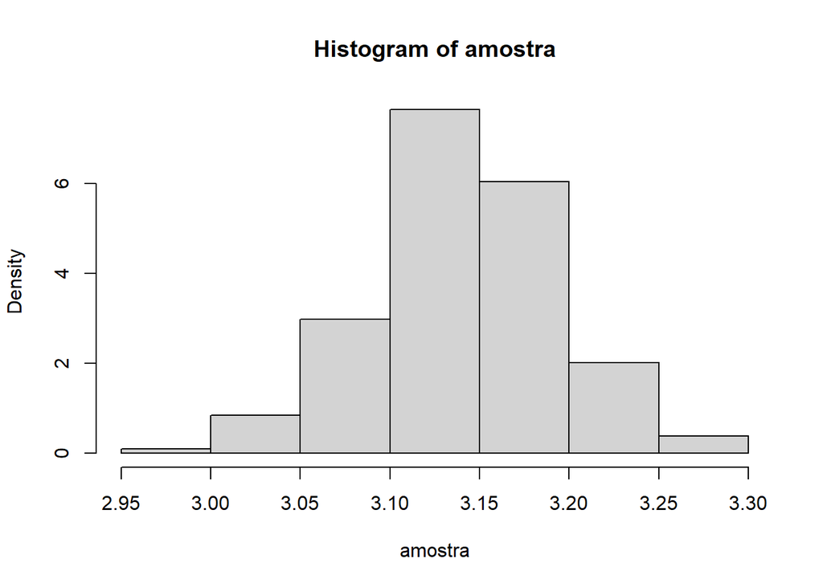

```r
hist(amostra, freq = F)
```

```r
mean(amostra)
```

```
## [1] 3.141568
```

```r
sum(quantis)/2
```

```
## [1] 3.14
```

Erro relativo $\frac{\hat\pi-\pi}{\pi}$

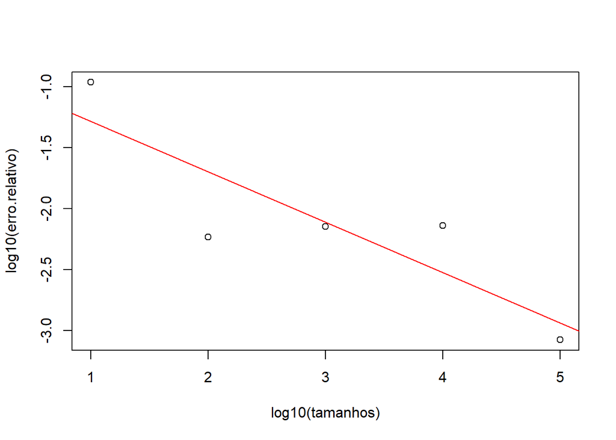

```r
tamanhos <- c(10^(1:5))

# erro.relativo <- abs((apply(replicate(1000,sapply(tamanhos,estima.pi)),1,mean)-pi)/pi) PARA 1000 REPETIÇÕES

erro.relativo <- abs((sapply(tamanhos,estima.pi) - pi)/pi)
plot(log10(tamanhos),log10(erro.relativo))
abline(lm(log10(erro.relativo)~log10(tamanhos)), col = "red")
```

```r
lm(log10(erro.relativo)~log10(tamanhos))
```

```
##
## Call:
## lm(formula = log10(erro.relativo) ~ log10(tamanhos))
##
## Coefficients:
##     (Intercept)  log10(tamanhos)
##         -0.8717          -0.4133
```

Exemplo das chaves

- EXEMPLO

$X_1,X_2,...,X_n \sim Cauchy$, com parâmetro de locação $\theta = 350$

$m(x)=\int_{-\infty}^\infty\prod_{i=1}^n\frac{1}{1 + (x_i-\theta)^2}d\theta$

```r
amostra <- rcauchy(10) + 350
veros <- function(theta){
   #u <- prod(dcauchy(amostra))
  u <- sapply(amostra,function(i)dcauchy(i-theta))
  u
  }
#integrate(veros,lower = -Inf,upper=Inf)
```